# Aprendizaje Profundo

# Minicurso de Inteligencia Artificial

## Introducción a Python

## Profesores

1. Alvaro Montenegro, PhD, ammontenegrod@unal.edu.co
2. Camilo José Torres Jiménez, Msc, cjtorresj@unal.edu.co
3. Daniel Montenegro, Msc, dextronomo@gmail.com

## Autores

1. Alvaro Montenegro, PhD, ammontenegrod@unal.edu.co
2. Daniel Montenegro, Msc, dextronomo@gmail.com
3. Oleg Jarma, Estadístico, ojarmam@unal.edu.co

## Asesora Medios y Marketing digital

4. Maria del Pilar Montenegro, pmontenegro88@gmail.com
5. Jessica López Mejía, jelopezme@unal.edu.co

## Jefe Jurídica

6. Paula Andrea Guzmán, guzmancruz.paula@gmail.com

## Coordinador Jurídico

7. David Fuentes

## Desarrolladores Principales

8. Dairo Moreno, damoralesj@unal.edu.co
9. Joan Castro, jelopezme@unal.edu.co
10. Bryan Riveros, briveros@unal.edu.co
11. Rosmer Vargas, rovargasc@unal.edu.co
12. Venus Puertas, vpuertasg@unal.edu.co

## Expertos en Bases de Datos

13. Giovvani Barrera, udgiovanni@gmail.com
14. Camilo Chitivo, cchitivo@unal.edu.co

## Programación tradicional y Científica

Siempre hay que tener la herramienta correcta para el problema indicado. En el caso de la programación, hay algunos lenguajes que hacen ciertas tareas mejores que otras.

[figure not shown]

Fuente: [Tumblr](https://64.media.tumblr.com/f07885ea54fdd1cc19461a5786a1d8fe/tumblr_inline_nv041bDxnI1raprkq_500.gifv)

### ¿Cuál sería un buen lenguaje para la Ciencia de Datos?

Este necesita tener lo siguiente:

- Capacidad para manejar y procesar datos.
- Sencillez para trabajar Algebra lineal y Matricial.
- Puede hacer optimización matemática de una forma comprensible.
- Herramientas de visualización(Gráficos, Dashboards, etc.).

Además algunas cosas que serían adecuadas:

- Código fácil de reproducir y entender.
- Curva de aprendizaje no muy empinada.

Hay muchas opciones de lenguajes especializados que cumplen estos prerrequisitos:

[figure not shown]

Pero vamos a ver algo un poco distinto.....

## Presentando.......Python

[figure not shown]

Python fue creado en 1991 por Guido Van Rossum con la intención de crear un lenguaje con enfoque en facilidad de lectura.

- Python es de **proposito general**, así que puede hacer una gran cantidad de software o aplicaciones
- Python es un lenguaje de **Alto nivel**, así que usa elementos de lenguaje natural y su sintaxis es compatible con la cognición humana.
- Es posible extender su uso gracias a "paquetes", que dan funcionalidad y herramientas especializadas para muchos trabajos.
- Funciona en diferentes **plataformas** (Windows, Mac, Linux, etc).
- Tiene una sintáxis que permite escribir programas en **muy pocas líneas**, comparado con otros lenguajes de programación.
- Python se ejecuta en un **sistema interpretado**. Es decir, que los códigos se pueden correr **justo después de ser escritos**; en otras palabras, no necesitan compilación previa.
- Se puede usar como un lenguaje **clásico**, como un lenguaje **orientado a objetos**, o como un lenguaje **funcional**.

la filosofía de python se resume en su **Zen**

```python
import this
```

```
The Zen of Python, by Tim Peters

Beautiful is better than ugly.
Explicit is better than implicit.
Simple is better than complex.
Complex is better than complicated.
Flat is better than nested.
Sparse is better than dense.
Readability counts.
Special cases aren't special enough to break the rules.
Although practicality beats purity.
Errors should never pass silently.
Unless explicitly silenced.
In the face of ambiguity, refuse the temptation to guess.
There should be one-- and preferably only one --obvious way to do it.
Although that way may not be obvious at first unless you're Dutch.
Now is better than never.
Although never is often better than *right* now.
If the implementation is hard to explain, it's a bad idea.
If the implementation is easy to explain, it may be a good idea.
Namespaces are one honking great idea -- let's do more of those!
```

## Cosas que se pueden hacer (Y se han hecho) con Python

- Puede ser usado en un servidor para crear **aplicaciones web**, o en diseñar **páginas web**
- Puede crear **aplicaciones de escritorio**, desde su funcionamiento base hasta su diseño.
- Puede conectarse a sistemas de **bases de datos** para leer y modificar archivos.
- Puede ser usado para manejar **Big Data** y hacer cálculos matemáticos de alta complejidad.
- Puede utilizarse para **Prototipado rápido** en producción de Software.

## ¿Quiénes usan Python?

Grandes empresas como Facebook/Meta, Dropbox, Netflix, Google y Spotify usan Python para múltiples tareas en formas muy distintas.

## ¿Por qué Python en Ciencia de Datos?

### Fácil de comenzar

Su estilo, su filosofía y su sintaxis hacen a python muy popular y fácil de aprender. Es sencillo encontrar documentación de los problemas que se encuentren.

### Paquetes especializados

Aunque sea de propósito general, gracias a los paquetes **numpy** y **pandas** entre otros, las capacidades de python pueden usarse directamente en aplicaciones matemáticas y estadísticas.

### Popularidad

Python es el lenguaje más usado en Ciencia de Datos

## Instalar Python

Recomendamos instalar python utilizando la distribución **Anaconda**. Tenemos un video detallando cómo

[figure not shown]

## Hello World!

El primer ejemplo clásico de programación es saludar, o sea, decirle al computador que muestre un saludo. Para esto, se usa la función de Python llamada **print**. Para colocar un saludo (o un **texto cualquiera**), se debe colocar entre **comillas dobles o sencillas** dentro del comando print. Entonces, para que el computador muestre un saludo, por ejemplo **Hello, World!**, debemos escribir en ambiente de código como sigue

```python
print('Hello world!')
```

```
Hello world!
```

## Variables en Python

Una variable sirve para **guardar un valor específico**, ya sea **numérico**, **texto** u otro **tipo de Dato** con el nombre con la que se nombre dicha variable. Observemos el siguiente ejemplo.

```python
# Asignamos 1 a la variable x

x = 1

print("El valor de la variable x es", x)

# Asignamos "¡Vamos a programar!" a la variable y

y = "¡Vamos a programar!"

print("\nEl valor de la variable y es", y)
```

```
El valor de la variable x es 1

El valor de la variable y es ¡Vamos a programar!
```

## Asignación dinámica en Python

En Python no es necesario declarar una variable de antemano, como ocurre en C, C++ y muchos otros lenguajes de bajo nivel. La asignación dińamica implica que es posible cambiar el tipo de dato de una variable con tan solo reasignarle un valor. En Python, se delega al programador la responsabilidad de cuidarse de efectos no esperados al cambiar el tipo de una variable. Veamos el siguiente ejemplo.

```python
x = 5.6
print('x es número un real:', x)

x = 3+4j
print('x es ahora un número complejo:', x)

x = '25 de mayo'
print('En cambio ahora x es un string:', x)
```

```
x es número un real: 5.6
x es ahora un número complejo: (3+4j)
En cambio ahora x es un string: 25 de mayo
```

## Reglas para la creación de variables

- El nombre de una variable **debe comenzar** con una letra ó con _.
- El nombre de una variable **no puede comenzar** con un número.
- El nombre de una variable **sólo puede contener** carácteres alfa-numéricos.
- El nombre de una variable tiene **sensibilidad** a **mayúsculas** y **minúsculas** (x es diferente de X).

## Tipos de datos básicos en Python

### Enteros (int)

Vea el siguiente ejemplo

```python
x = 1
print(x)
print(type(x))
x = 1000000000000000000000000000000000000000000000000000000000000000000000000000000000000000000001
print(x)
print(type(x))
```

```
1
<class 'int'>
1000000000000000000000000000000000000000000000000000000000000000000000000000000000000000000001
<class 'int'>
```

Se observan dos cosas interesantes. Primero, el tipo de dato es una clase 'int'. Todo en Pyhon son objetos, incluidos la variables simples. En otro cuaderno estudiaremos las clases y objetos en detalle.

Segundo, En python puede tener números enteros tan grandes como desee, a diferencia de otros lenguajes.

### Punto Flotante (float)

Lo número reales son representados usando el estándar IEEE 754 double precision.

```python
x = 1.56
print(x)
print(type(x))
```

```
1.56
<class 'float'>
```

### Números complejos (complex)

Se representan en la forma $a + bj$, en donde $a$ es la parte real y $ b$ la parte imaginaria

```python
z = 3.4 + 4j
print(z)
print(type(z))
```

```
(3.4+4j)
<class 'complex'>
```

### Booleanas (bool)

El tipo booleano se utiliza para variables que solamente pueden ser 'True' o 'False', es decir, valores booleanos o lógicos. Por ejemplo:

```python
t = True
print(t)
print(type(t))
```

```
True
<class 'bool'>
```

### None

Este es un tipo especial de dato utilizado para indicar que una determinada variable no contiene ningún dato. Es muy útil en el control de muchas situaciones, porque sirve para saber si algún objeto a llegado a ser None. Mire el siguiente ejemplo.

```python
b = None
print(b)
print(type(b))

z = 5

b is None
```

```
None
<class 'NoneType'>
```

```
True
```

### Texto o Strings

Los string son expresiones que representan una cadena de caracteres, útiles para escribir mensajes y combinarlos con valores que generemos en nuestros procesamientos. Para escribir un texto en Python usamos comillas simples: `'...'` o comillas dobles: `"..."`. Combinamos comillas para poner comillas adentro:

Como vimos, la función print es la que nos permite imprimir estos mensajes. El texto \n indica una nueva linea en el texto:

```python
print("Una línea\nOtra línea")
```

```
Una línea
Otra línea
```

Podemos recorrer los valores de la cadena de texto de la siguiente forma:

```python
texto="cuidado_con_el_orden"
texto
```

```
'cuidado_con_el_orden'
```

Extrayendo el elemento cero del texto (**primer caracter**):

```python
print(texto[0])
```

```
c
```

Extrayendo el elemento uno del texto (**segundo caracter**):

```python
texto[1]
```

```
'u'
```

Extrayendo el elemento cinco hasta el elemento 9 del texto (**sin incluir el 9**):

```python
texto[5:9]
```

```
'do_c'
```

**También se pueden usar índices negativos** (Exclusivo de Python):

```python
texto[3:-1]
```

```
'dado_con_el_orde'
```

```python
texto[-1]
```

```
'n'
```

## Suma de variables y concatenación de variables

Python es tan sencillo e intuitivo, que es posible sumar diferentes variables y sumarlas con el símbolo **+**. Cuando las variables son numéricas, se **suman matemáticamente** y cuando es texto se **concatenan**.

```python
# Sumar dos textos

x = "Python es ";
y = "asombroso";
z =  x + str(y);
print(z);

# Sumar dos números

n1 = 1;
n2 = 5;
suma = n1 + n2;
print(suma);

# Escribir texto y números
print(x+"el número",n1);
```

```
Python es asombroso
6
Python es el número 1
```

## Operadores Aritméticos y redondeo

La fortuna de que Python reconozca variables numéricas nos permite usarla como una calculadora simple, podemos ejecutar operaciones muy sencillas teniendo en cuenta la siguiente tabla:

| **Operador** | **Descripción** |
| --- | --- |
| `+` | Suma |
| `-` | Resta |
| `*` | Multiplicación |
| `/` | División |
| `**` | Potencia |

### Ejemplo

Si queremos operar:

$$ 5\times(3-5)^2-\cfrac{6}{(9)^{1/2}}$$

tenemos que escribir:

```python
5*(3-5)**2-(6)/(9**(1/2))
```

```
18.0
```

### División y residuo entre enteros

La división es una operación bien especial pues la mayoría de ocasiones produce un número con parte fraccionaria. Sin embargo, cuando estábamos pequeños nos enseñaron a dividir enteros dando como respuesta un entero llamado cociente y lo que hacia falta para completar la división, un número llamado residuo. En Python podemos calcular esos valores con `\\` para el cociente y `%`para el residuo. Por ejemplo, sabemos que:

$$ 20 \div 3 = 6 \ \ \ \text{ con residuo } 2$$

tenemos:

```python
20//3
```

```
6
```

```python
20%3
```

```
2
```

Finalmente, una función elemental y útil para el tratamiento de números decimales es `round`. Lo usamos para redondear los valores a uno con el decimal que escojamos. Tenemos:

```python
n1=47/3
n1
```

```
15.666666666666666
```

```python
n2=round(n1)
n2
```

```
16
```

```python
n3=round(n1,3)
n3
```

```
15.667
```

## Flujo de control

El flujo de control de un programa se refiere al orden en el que el código se va ejecutando y qué se ejecuta exactamente. Podemos verlo de alguna manera como la jerarquía de operaciones.

En Python, y cualquier lenguaje de programación, el flujo es regulado por tres estructuras de control:

- Secuencial
- Selección/Decisión
- Repetición

### Estructura Secuencial

El modo "default" que siempre está presente. Por la naturaleza interpretada de Python, el código se ejecuta en orden ascendente

#### Ejemplo

Observemos el siguiente código Python

```python
x = 1;
y = 2;

print(x,y)
```

```
1 2
```

En el ejemplo hay tres sentencias. Dos sentencias de asignación de valores y una sentencia de impresión. Se ejecuta una después de la otra. Si se escribe la sentencia de impresión primero, el código completo falla.

### Estructura de Selección

Estas sentencias permiten al programa probar diferentes condiciones y ejecutar código dependiendo de cuál condición es "verdadera"

La estructura de selección clásica es el "if"

```python
# ejemplo if
x = 5
y = 3

if x>y:
    print("Cinco es mayor que Tres")
    print("lunes")
```

```
Cinco es mayor que Tres
lunes
```

La estructura empieza con la palabra clave **if**. Luego aparece una condición lógica que es evaluada (x>y). Si la condición es verdadera, como en este caso, se ejecutan las instrucciones escritas dentro de la estructura.

Podemos extender el uso del if con "else if" y "else"

```python
x = 5
y = 6

if x>y:
    print(x, " es mayor que ", y)
elif y>x:
    print("{} es mayor que {}".format(y,x))
else:
    print("ambos números son iguales")
```

```
6 es mayor que 5
```

#### Operadores de comparación

| **Operador** | **Descripción** | **Ejemplo** |
| --- | --- | --- |
| `==` | Prueba si dos valores son iguales | 3==3 |
| `!=` | Prueba si dos valores no son iguales entren si | 2!=3 |
| `<` | Prueba si el valor de la izquierza es menor que el de la derecha | 4<3 |
| `>` | Prueba si el valor de la izquierza es mayor que el de la derecha | 4<3 |
| `<=` | Prueba si el valor de la izquierza es menor o igual que el de la derecha | 4<=3 |
| `>=` | Prueba si el valor de la izquierza es mayor igual que el de la derecha | 4<=3 |

#### Operadores Lógicos

| **Operador** | **Descripción** | **Ejemplo** |
| --- | --- | --- |
| `and` | Regresa verdadero si el valor de las izquierda y el de la derecha son verdaderos | (3<4) and (5>1) |
| `or` | Regresa verdadero si uno de los dos valores a(izquierda o derecha es verdadero, o ambos | (3<4) or (5<1) |
| `not` | Regresa verdadero si el valor que se esta evaluado es falso | not 3>2 |

### Estructura de repetición [ciclos]

Este tercer tipo de estructura de control se usa para los casos en los cuales es necesario correr un proceso varas veces en forma continua.

#### Ciclo while

Al comienzo del ciclo se evalúa una condición. Si la condición es verdadera se ejecuta de nuevo el ciclo. En otro caso, termina. Corra y analice el siguiente fragmento (snippet) de código

```python
contador = 0

print('Starting')
while contador < 10:
    #Instrucciones útiles
    print(contador,' ', end='')
    contador = contador + 1

print()
print('Done')
```

```
Starting
0  1  2  3  4  5  6  7  8  9
Done
```

#### Ciclo for

En este caso se usa una variable de salto que va recorriendo un conjunto de valores hasta terminar. Revise el siguiente snippet.

```python
print('\nStart:')
for i in range(20):
    # Instrucciones útiles
    print(i, ' ', end='')

print('\nDone.')
```

```
Start:
0  1  2  3  4  5  6  7  8  9  10  11  12  13  14  15  16  17  18  19
Done.
```

#### Break

Se usa para terminar la ejecución de un ciclo while o for. Corra el siguiente ejemplo dadno difentes valores.

```python
for  i in range(10):
    print(i)
    if i==5:
        break
```

```
0
1
2
3
4
5
```

### Estructuras de control anidadas

Es posible incluir (o anidar) estructuras de control dentro de otras estructuras de control.

Esto es de gran utilidad para realizar programas de mayor complejidad.

**Ejemplo:**

```python
x = 5
y = 3
if x>y:
    for i in range(5):
        print(i)
    x = 9.9
else:
    for i in reversed(range(5)):
        print(i)
    x = False
y = 2
print(x, y)
```

```
0
1
2
3
4
9.9 2
```

Podemos anidar el mismo tipo de estructura sin problema

```python
for i in range(0,11):
    for j in range(i):
        print('*', end='')
    print('')
```

[output not shown]

## Estructuras de datos

Las estructuras de datos son constructos esenciales en python y en la programación en general, ya que son la base de muchos programas o aplicaciones.

Cada tipo de estructura nos muestra una forma de guardar, organizar y acceder a los datos. Cada una tiene sus ventajas particulares.

### Listas

La estructura más flexible en el nucleo de Python. Las llamamos con `[ ]`. Este puede guardar esencialmente cualquier tipo de elemento.

```python
arr = [1, 2, 3, 4]
print(arr)
```

```
[1, 2, 3, 4]
```

Los objetos guardados no tienen que ser del mismo tipo. De hecho, no tiene que haber objetos dentro de la lista para crearla

```python
arr = [1, 1.0, "a", True, None]
print(arr)
arr = []
print(arr)
```

```
[1, 1.0, 'a', True, None]
[]
```

De forma similar a los Strings, podemos obtener los elementos individuales de una lista a través de sus indices.

```python
arr = [1, 2, 3, 4]

print(arr[0])
print(arr[1:3])
print(arr[-1])
```

```
1
[2, 3]
4
```

Es posible hacer cambios en las listas, como agregar, sobreescribir y eliminar elementos

```python
arr.append(7)
print(arr)
arr[2] = 3.0
print(arr)
del arr[0]
print(arr)
```

```
[1, 2, 3, 4, 7]
[1, 2, 3.0, 4, 7]
[2, 3.0, 4, 7]
```

Las listas pueden incluso tener listas dentro!

```python
list_list = []

x = 10

for i in range(x):
    inside_list = []
    for j in range(i+1):
        inside_list.append(j)
    list_list.append(inside_list)
print(list_list)
```

```
[[0], [0, 1], [0, 1, 2], [0, 1, 2, 3], [0, 1, 2, 3, 4], [0, 1, 2, 3, 4, 5], [0, 1, 2, 3, 4, 5, 6], [0, 1, 2, 3, 4, 5, 6, 7], [0, 1, 2, 3, 4, 5, 6, 7, 8], [0, 1, 2, 3, 4, 5, 6, 7, 8, 9]]
```

### Tuplas

Similares a las listas, solo que no podemos aplicarles cambios. Son "inmutables". Las llamamos con `( )`

```python
t1 = ("Hola mundo", 4j-1, 3333333333333333, False)
print(t1)
```

```
('Hola mundo', (-1+4j), 3333333333333333, False)
```

Es posible crear una tupla a partir de una lista

```python
lis_to_tup = tuple(arr)
print(lis_to_tup)
```

```
(2, 3.0, 4, 7)
```

Tanto las lista como las tuplas pueden contener objetos muy complejos, hasta el punto que puede ser confuso.

```python
t1 = (1, 'Oleg', 24.5)
l1 = ['Maria', 'Bonita']
l2 = [t1, l1]
t2 = (l2,'manzana')

print('t1=', t1)
print('l1=', l1)
print('l2=', l2)
print('t2=', t2)
```

```
t1= (1, 'Oleg', 24.5)
l1= ['Maria', 'Bonita']
l2= [(1, 'Oleg', 24.5), ['Maria', 'Bonita']]
t2= ([(1, 'Oleg', 24.5), ['Maria', 'Bonita']], 'manzana')
```

### Diccionarios

Estos son estructuras muy distintas a las anteriores, ya que los datos guardados son indexados junto con un elemento especial llamado "Llave". Podemos verlo como una guía telefónica o una lista de contactos: el nombre es la llave del número de teléfono

Estos se llaman usando `{}`

```python
contactos ={
    "Juan": 6013335555,
    "Ana": 6032224466,
    "David": 6012556644
}
print(contactos)
```

```
{'Juan': 6013335555, 'Ana': 6032224466, 'David': 6012556644}
```

Cualquier elemento puede ser llave de cualquier elemento.

```python
dic1 = {
    33: "Zapato",
    True: 44.1,
    "Nombre": ["David", "Lisa"],
    (25.5, 33.6): (33.6, 25.5)
}
print(dic1)
```

```
{33: 'Zapato', True: 44.1, 'Nombre': ['David', 'Lisa'], (25.5, 33.6): (33.6, 25.5)}
```

Los diccionarios pueden modificarse de las mismas maneras que una lista

```python
contactos["Pedro"] = 6016669999

contactos["David"] = 6015224466

del contactos["Ana"]

print(contactos)
```

```
{'Juan': 6013335555, 'David': 6015224466, 'Pedro': 6016669999}
```

Los diccionarios son muy poderosos ya que podemos incrementar su tamaño sin generar error:

```python
#Generar diccionario vacío
persona = {}
print(type(persona))

# Agregar llaves y sus definiciones (items)
persona['Nombre'] = 'Gengis'
persona['Apellido'] = 'Khan'
persona['Edad'] = 23
persona['Esposa'] = ['Börte Qatun','Yesugen','Qulan Qatun','Möge Qatun','Juerbiesu','Ibaqa Beki']
persona['Hijos'] = 'En estudio'
persona['Mascotas'] = {'Perro': 'Wahadi', 'Gato': 'Gotze','Leon':'Pichirilo'}

print(persona)
print('Hijos de',persona['Nombre'],':',persona['Hijos'])
```

```
<class 'dict'>
{'Nombre': 'Gengis', 'Apellido': 'Khan', 'Edad': 23, 'Esposa': ['Börte Qatun', 'Yesugen', 'Qulan Qatun', 'Möge Qatun', 'Juerbiesu', 'Ibaqa Beki'], 'Hijos': 'En estudio', 'Mascotas': {'Perro': 'Wahadi', 'Gato': 'Gotze', 'Leon': 'Pichirilo'}}
Hijos de Gengis : En estudio
```

Del ejemplo anterior se puede observar que los diccionarios pueden contener diccionarios en su interior:

```python
print(persona['Mascotas'])
```

```
{'Perro': 'Wahadi', 'Gato': 'Gotze', 'Leon': 'Pichirilo'}
```

```python
print(persona['Mascotas']['Perro'])
```

```
Wahadi
```

## Funciones

Todo el código que hemos visto antes tiene un pequeño problema: Ha sido escrito completamente manual. Si queríamos aplicar procesos parecidos, hubo que copiar y pegar el mismo código y actualizarlo. Incluso si queremos volver a definir variables, tuvimos que re escribirlo completamente.

Las funciones en Python nos permiten re utilizar código de una forma sencilla y rápida. Definimos un código de manera premeditada y este únicamente corre en el momento que lo llamemos.

para definir una función justamente usamos `def`. Hagamos una función "Hello World"

```python
def hello_world(name):
    print("Hola mundo, mi nombre es {}".format(name))
```

Como se ve, no se imprime nada todavía, tenemos que llamar la nueva función.

```python
hello_world("Oleg")
```

```
Hola mundo, mi nombre es Oleg
```

Podemos definir cualquier tipo de código y utilizar cualquier estructura que hemos visto.

```python
def create_contacts(name_list, phone_list):
    contacts = {}
    for name, number in zip(name_list, phone_list):
        contacts[name] = number
    print(contacts)

nombres = ["David", "Sara", "Santiago", "Diana"]
numeros = [2323, 55555, 23497234, 68420342]

create_contacts(nombres, numeros)
```

```
{'David': 2323, 'Sara': 55555, 'Santiago': 23497234, 'Diana': 68420342}
```

las funciones también pueden retornar variables cuando se llaman usando `return`

```python
def get_evens(number_list):
    even = []
    for num in number_list:
        if num%2 == 0:
            even.append(num)
    return(even)
numbers = [12312341521, 33453125, 11, 23, 56, 12394871434, 77777776, 12314]

for i in get_evens(numbers):
    print(i)
```

```
56
12394871434
77777776
12314
```

Un ejemplo final de lo que podemos aplicar con las funciones

```python
import numpy as np
import matplotlib.pyplot as plt

plt.rcParams["figure.figsize"] = [7.50, 3.50]
plt.rcParams["figure.autolayout"] = True



def plot_function(f, bounds=(-10,10), color="blue"):
    x = np.linspace(bounds[0], bounds[1], 100)
    plt.plot(x, f(x), color=color)
```

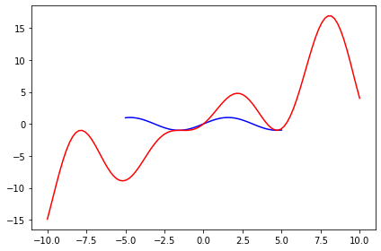

```python
def f(x):
    return np.sin(x) + x + x * np.sin(x)


plot_function(np.sin, (-5,5))
plot_function(f, color="red")
plt.show()
```

Compliquemos un poco la situación

¿Alguno conoce la "ecuación de Batman"?

[figure not shown]

```python
def plot_symmetric(f, bounds=(-10,10), color="blue"):
    x = np.linspace(bounds[0], bounds[1], 100)
    plt.plot(x, f(x), color=color)
    plt.plot(np.flip(-x), f(np.flip(-x)), color=color)

def y1(x):
    return abs(x/2)- 0.09137*x**2 + np.sqrt(1-(abs(abs(x)-2)-1)**2) -3

def y2(x):
    return 3*np.sqrt(-(x/7)**2+1)

def y3(x):
    return -3*np.sqrt(-(x/7)**2+1)

def y4(x):
    return 9-8*abs(x)

def y5(x):
    return 1.5 - .5*abs(x) - 1.89736*(np.sqrt(3-x**2+2*abs(x))-2)

def y6(x):
    return 3*abs(x)+.75

def y7(x):
    return np.full(len(x), 2.25)
```

[figure not shown]

```python
plt.rcParams["axes.facecolor"] = 'black'

plot_function(y1, (-4,4), color="yellow")
plot_function(y7, (-.5,.5), color="yellow")
plot_symmetric(y2, (3,7), color="yellow")
plot_symmetric(y3, (-7,-4), color="yellow")
plot_symmetric(y4, (-1,-.75), color="yellow")
plot_symmetric(y5, (-2.9,-1), color="yellow")
plot_symmetric(y6, (-.75,-.5), color="yellow")
```